# Benefits and risks associated with children’s and adolescents’ interactions with electronic screens: An umbrella review

Taren Sanders (Institute for Positive Psychology and Education, ACU)https://www.acu.edu.au/research/our-research-institutes/institute-for-positive-psychology-and-education , Michael Noetel (School of Health and Behavioural Sciences, ACU)https://www.acu.edu.au/about-acu/faculties-directorates-and-staff/faculty-of-health-sciences/school-of-behavioural-and-health-sciences , Philip Parker (Institute for Positive Psychology and Education, ACU)https://www.acu.edu.au/research/our-research-institutes/institute-for-positive-psychology-and-education , Borja Del Pozo Cruz , Stuart Biddle , Rimante Ronto , Ryan Hulteen , Rhiannon Parker , George Thomas , Katrien De Cocker , Jo Salmon , Kylie Hesketh , Nicole Weeks , Hugh Arnott , Emma Devine , Roberta Vasconcellos , Chris Lonsdale (Institute for Positive Psychology and Education, ACU)https://www.acu.edu.au/research/our-research-institutes/institute-for-positive-psychology-and-education  
2022-01-11

# Background

In the 16th century, hysteria reigned around a new technology that threatened to be “confusing and harmful” to the mind. The cause of such concern? The widespread availability of books brought about by the invention of the printing press [1]. In the early 19th century, concerns about schooling “exhausting the children’s brains” followed, with the medical community accepting that excessive study could be a cause of madness [2]. By the 20th century, the invention of the radio was accompanied by assertions that it would distract children from their reading (which by this point was no longer considered confusing and harmful) leading to impaired learning [3].

Today, the same arguments that were once leveled against reading, schooling, and radio are being made about screen use (e.g., television, mobile phones, and computers) [4]. Excessive screen time use is the number one concern parents have about their children’s health and behaviour, ahead of nutrition, bullying, and physical inactivity [5]. Yet, the evidence to support parents’ concerns is inadequate. A Lancet editorial [6] suggested that, “Our understanding of the benefits, harms, and risks of our rapidly changing digital landscape is sorely lacking.”

While some forms of screen use (e.g., television viewing) may be detrimental to behaviour and health [7,8], evidence for other forms of screen exposure (e.g., video games or online communication, such as Zoom) remains less certain and, in some cases, may even be beneficial [9,10]. Thus, according to a Nature Human Behaviour editorial, research to determine the effect of screen exposure on youth is “a defining challenge of the digital age” [11]. With concerns over the impact of screen use including education, health, social development, and psychological well-being, a broad overview that identifies potential benefits and risks is needed.

Citing the negative effects on health (e.g., increased risk of obesity) and health-related behaviours (e.g., sleep), guidelines from the World Health Organisation [12] and numerous government agencies [13,14] and statements by expert groups [15] have recommended that young people’s time spent using electronic media devices for entertainment purposes should be limited. For example, the Australian Government guidelines regarding sedentary behaviour recommend that young children (under the age of two) should not spend any time watching screens. They also recommend that children aged 2-5 years should spend a maximum of one hour engaged in recreational sedentary screen use per day, while children aged 5-12 and adolescents should spend no more than two hours. In contrast, some recent evidence suggests that exposure to electronic entertainment media that exceeds these guidelines (e.g., 3-4 hours per day) may not have meaningful adverse effects on children’s behaviour or mental health [16], and might, in fact, benefit their well-being, as long as this exposure does not reach extreme levels (e.g., 7 hours per day). Some research also indicates that content (e.g., video games vs television programs) may also play an important role in determining the potential benefit or harm of youths’ exposure to screen-based media [17]. Indeed, educational screen time is positively related to educational outcomes [18]. This evidence has led some researchers to argue that a more nuanced approach to screen time guidelines is required.

In 2016, the American Academy of Pediatrics used a narrative review to examine the benefits and risks of children and adolescents’ electronic media [19] as a basis for updating their guidelines about screen use [15]. Since then, a large number of systematic reviews and meta-analyses have provided evidence about the potential benefits and risks of screen use. Yet, no review has synthesised the evidence available across a broad range of outcome domains, such as physical health, education, development, behaviour, and well-being.

In order to crystallise the evidence base and support further evidence-based guideline development and refinement, we reviewed published meta-analyses examining the effects of screen use on children and youth. This review synthesises evidence on any plausible outcome of electronic media exposure. Adopting this broad approach allowed us to provide a holistic perspective on the influence of screens on children’s lives. By synthesising across life domains (e.g., school and home), this review provides evidence to support better guidelines and advice for parents, teachers, pediatricians and other professionals in order to maximise human functioning.

# Methods

### Eligibility criteria

*Population*: To be eligible for inclusion, meta-analyses needed to include meta-analytic effect sizes for children or adolescents (age 0-18 years). We included meta-analyses containing studies that combined data from adults and youth if meta-analytic effect size estimates specific to participants aged 18 years or less could be extracted (i.e., the highest individual study from the meta-analysis had a mean age was < 18 years). We excluded meta-analyses that only contained evidence gathered from adults (age >18 years).

*Exposure*: We included meta-analyses examining all types of electronic screens including (but not necessarily limited to) television, gaming consoles, computer, tablet, and mobile phones. We also included analyses of all types of content on these devices, including (but not necessarily limited to) recreational content (e.g., television programs, movies, games), homework, and communication (e.g., video chat). In this review we adopted a population-level perspective, meaning that we examined electronic media exposure that occurs during typical daily living activities (e.g., home, school-based electronic media exposure). Consistent with this population-level approach, we excluded technology-based treatments for clinical conditions. However, we included studies examining the effect of screen exposure on non-clinical outcomes (e.g., learning children) for children and youth with a clinical condition. For example, a meta-analysis of the effect of television watching on learning among adolescents diagnosed with depression would be included. However, a meta-analysis of interventions designed to treat clinical depression delivered by a mobile phone app would be excluded.

*Outcomes*: We included all reported outcomes.

*Publications*:We included meta-analyses (or meta-regressions) of quantitative evidence. To be included, meta-analyses needed to analyse data from studies identified in a systematic review. For our purposes, a systematic review was one in which the authors attempted to acquire all the research evidence that pertained to their research question(s). We excluded meta-analyses that did not attempt to summarise all the available evidence (e.g., a meta-analysis of all studies from one laboratory). We included meta-analyses regardless of the study designs included in the review (e.g., laboratory-based experimental studies, randomised controlled trials, non-randomised controlled trials, longitudinal, cross-sectional, case studies), as long as the studies in the review collected quantitative evidence. We excluded systematic reviews of qualitative evidence. We did not formulate inclusion/exclusion criteria related to the risk of bias of the review. We did, however, employ a risk of bias tool to help interpret the results. We included full-text, peer-reviewed meta-analyses published or ‘in-press’ in English. We excluded conference abstracts and meta-analyses that were unpublished.

### Information sources

We searched records contained in the following databases: Pubmed, MEDLINE, CINAHL, PsycINFO, SPORTDiscus, Education Source, Embase, Cochrane Library, Scopus, Web of Science, ProQuest Social Science Premium Collection, and ERIC. We conducted an initial search on August 17, 2018 and refreshed the search on May 13, 2020. We searched reference lists of included papers in order to identify additional eligible meta-analyses. We also searched PROSPERO to identify relevant protocols and contacted authors to determine if these reviews have been completed and published.

### Search strategy

The search strategy associated with each of the 12 databases can be found [here](https://docs.google.com/document/d/1hz5Dgw0aVOMeXL3vpRXsNtCIbf6dHZTb8uz7wQ29ke4/edit#heading=h.i6znptfz9nwa). We hand searched reference lists from any relevant umbrella reviews to identify systematic meta-analyses that our search may have missed.

### Selection process

Using Covidence software (Veritas Health Innovation, Melbourne, Australia), two researchers independently screened all titles and abstracts. Two researchers then independently reviewed full-text articles. We resolved disagreements at each stage of the process by consensus, with a third researcher employed, when needed.

### Data collection process

From each included meta-analysis, two researchers independently extracted data into a custom-designed database.

### Data items

From each meta-analysis we extracted the following items: First author, year of publication, study design restrictions (e.g., cross-sectional, observational, experimental), region restrictions (e.g., specific countries), earliest and latest study publication dates, sample age (mean), lowest and highest mean age reported, outcomes reported, and exposures reported.

### Study risk of bias assessment

For each meta-analysis, two researchers independently completed the National Health, Lung and Blood Institute’s Quality Assessment of Systematic Reviews and Meta-Analyses tool [20] (see Table 1). We resolved disagreements by consensus, with a third researcher employed when needed. We did not assess risk of bias in the individual studies that were included in each meta-analysis.

### Effect measures

Two researchers independently extracted all quantitative meta-analytic effect sizes, including moderation results. Where possible, they also extracted effect sizes from primary studies included in each meta-analysis. To facilitate comparisons, we converted effect sizes to Pearson’s $r$ using established formulae [21–23]. We excluded relative risk ratios from this conversion because meta-analyses did not contain sufficient information to meaningfully convert. Effect sizes on the original metric are provided in [Supplementary File 1](https://drive.google.com/file/d/1icdKoSdaOs5c8X6Ugmm0qLW_CEFSWDDu/view?usp=sharing).

### Synthesis methods

After extracting data, we examined the combinations of exposure and outcomes and removed any effects that appeared more than once, keeping the effect with the largest total sample size. In instances where effect sizes from the same combination of exposure and outcome were drawn from different populations (e.g., children vs adolescents) we retained both estimates in our dataset.

We excluded effect size estimates when the authors did not provide a sample size. We descriptively present the remaining meta-analytic effect sizes. When the meta-analysis’s authors provided primary study data associated with these effects we reran the effect size estimate using a random effects meta-analysis via the metafor package [24] in R [25] (version 4.1.2). When required, we imputed missing sample sizes using mean imputation from the other studies within that review. From our reanalysis we also extracted $I^2$ values. To test for publication bias, we conducted Egger’s test [26] when the number of studies within the review was ten or more [27], and conducted a test of excess significance [28]. We contacted authors who did not provide primary study data in their published article. Where authors did not provide data in a format that could be re-analysed, we used the published results of their original meta-analysis.

### Evidence assessment criteria

*Statistical Credibility*. We employed a statistical classification approach to grade the statistical credibility of the effect sizes in the literature. To be considered credible an effect needed to be derived from a combined sample of >1,000 [29] and have non-significant tests of publication bias (i.e., Egger’s test and excess significance test). We performed these analyses, and therefore the review needed to provide usable study-level data in order to be included.

*Consistency of Effect within the Population*. We also examined the consistency of the effect size using the $I^2$ measure. We considered $I^2 < 50\%$ to indicate effects that were relatively consistent across the population of interest. $I^2$ values of $> 50\%$ were taken to indicate an effect was potentially heterogeneous within the population.

*Direction of Effect*. Finally, we examined the extent to which significance testing suggested screen exposure was associated with benefit, harm, or no effect on outcomes. We used thresholds of $P < .05$ for weak evidence and $P < 10^{-3}$ for strong evidence. An effect that was neither significant at $P < .05$ or $10^{-3}$ that also passed the criteria for statistical credibility was taken to indicate no association of interest.

### Deviations from protocol

We initially planned to include systematic reviews without meta-analyses in a narrative summary alongside the main meta-analytic findings. However, we determined that combining results from the meta-analyses provided a robust overview. Readers interested in the relevant systematic reviews (i.e., without meta-analysis) can consult the list of references in [Supplementary File 2](https://drive.google.com/file/d/1JhMsySEyfby5MtcUcIVpp0LjDDfTA5IH/view?usp=sharing).

We altered our evidence assessment plan when we identified that, as written, it would treat effects from large reviews, with limited evidence of publication bias, and with consistency of effect in the population as not credible if the effect size was not statistically significant. This would have significantly harmed knowledge gained from our review as it would have restricted our ability to show where the empirical evidence strongly indicated that there was no association between screen time and a given outcome.

# Results

### Search Results

The searches yielded 41,928 results, of which 24,023 were duplicates. After screening titles and abstracts, we assessed 1,964 full-texts for inclusion. One hundred and seventeen met the inclusion criteria and we extracted the data from these meta-analyses. Figure 1 presents the full results of the selection process.

[interactive chart not shown]

Figure 1: PRISMA Diagram

The most frequently reported exposures were general tv programs and movies (n = 26), physically active video games (n = 15), screen-based lifestyle risk behaviour interventions (at school) (n = 14), and general screen use (n = 13). [Supplementary File 3](https://drive.google.com/file/d/12rB0ihW9Hi1kxM-8AIBfjdCMO6TqP28n/view?usp=sharing) provides a list of all exposures identified. The most frequently reported outcomes were body composition (n = 34), general physical activity (n = 15), general literacy (n = 13), general learning (n = 12), and duration sleep (n = 9). In most cases (121/197), there was only one exposure/outcome combination for an age group, with 20 appearing twice, and 8 appearing three or more times. Full characteristics of the included studies are provided in Table 1. Our process yielded 167 unique effects/outcome combinations contributed from 51 reviews. These effects represent the findings of 2,171 primary studies comprised of 1,652,944 participants.

Table 1: Review characteristics and quality assessment for studies providing unique effects

**Study Characteristics**

Review characteristics and quality assessment for studies providing unique effects

Review Characteristics

Quality Assessment<sup>1</sup>

First Author

Year

Design Restrictions

Regions Restrictions

Study Range  
Earliest - Latest

Sample Age Restrictions  
(Age Range)<sup>2</sup>

Outcomes Assessed

Exposures Assessed

Elig.  
Crit.<sup>3</sup>

Lit. Search<sup>4</sup>

Dual Screening<sup>5</sup>

Dual Quality<sup>6</sup>

Studies Listed<sup>7</sup>

Pub. Bias Assessed<sup>8</sup>

Heterog. Assessed<sup>9</sup>

Abrami

2015

Include: Experimental; Quasi-experimental

None specified

2009–2015

School-age Children (Early Primary/Elementary)

- Literacy: Listening comprehension
- Literacy: Phonics
- Literacy: Phonomic awareness
- Literacy: Reading comprehension
- Literacy: Reading fluency
- Literacy: Vocabulary knowledge
- Intervention: Literacy (Abracadabra; in schools)

High

High

Low

High

Low

Low

Low

Adelantado-Renau

2019

Include: Cross-sectional studies

None specified

1982–2019

Children; Adolescents  
(5.7-18.0)

- Learning: General
- Literacy: General
- Numeracy: General
- Screen use: General
- TV programs and movies: General
- Video games: General

Low

Low

Low

Low

Low

Low

Low

Aghasi

2020

Include: Observational

None specified

2007–2016

All  
(14.2-15.8)

- Body composition
- Internet use: General

Unclear

Low

Low

Unclear

Low

Low

Low

Andrade

2019

Include: Interventions

None specified

2010–2017

Children; Adolescents

- Healthy behavior: Self-efficacy
- Psychological health: Depression
- Psychological health: Enjoyment
- Self-perceptions: General
- Self-perceptions: Self-esteem
- Video games: Physically active

Unclear

Low

Low

Unclear

Low

High

Low

Bartel

2015

None

None specified

2004–2014

Adolescents  
(12.2-17.7)

- Sleep: Bedtime
- Sleep: Duration
- Sleep: Time to fall asleep
- Computer use: General
- Internet use: General
- Screen use: General (mobile phone)
- TV programs and movies: General
- Video game console: General

Low

Low

Unclear

Unclear

Low

Unclear

Unclear

Blok

2002

None

None specified

1990–2000

All  
(5.4-11.5)

- Literacy: Reading fluency
- Intervention: Literacy

Unclear

Low

High

High

Low

High

Low

Bossen

2020

Include: Randomised controlled trials

None specified

2011–2018

Children  
(10.0-15.7)

- Body composition
- Cardiometabolic health: Fitness
- Physical activity: General
- Physical health: Muscular fitness
- Video games: Health promoting content

Unclear

Low

Low

Low

Low

High

Low

Boyland

2016

Include: Experimental

None specified

2004–2015

Children; Adolescents  
(6.0-10.4)

- Diet: Food intake
- Advertising: Unhealthy food

High

Low

Low

Unclear

Low

Low

Low

Byun

2018

Include: All quantitative designs

None specified

2006–2014

School-age Children

- Numeracy: General
- Video games: Numeracy

Unclear

Unclear

Unclear

High

High

High

High

Carter

2016

Include: All quantitative designs

None specified

2011–2015

Children; Adolescents  
(10.6-17.0)

- Sleep: Inadequate duration
- Sleep: Lethargy
- Sleep: Poor quality
- Screen use: General (mobile phone at bed time)

Low

Low

Unclear

Low

Low

High

Low

Champion

2019

Include: Randomised controlled trials

None specified

2003–2017

School-age Children  
(11.4-15.9)

- Body composition
- Diet: Fat consumption
- Diet: Fruit and vegetable intake
- Diet: Fruit intake
- Diet: Sugary drinks & snacks
- Physical activity: General
- Physical activity: Moderate-to-vigorous intensity
- Risky behavior: Alcohol consumption
- Risky behavior: Smoking
- Screen time: General
- Intervention: Lifestyle risk behaviour (at school)

Low

Low

Low

Low

Low

Low

Low

Chan

2014

Include: Experimental; Quasi-experimental

None specified

2002–2012

School-age Children

- Numeracy: General
- Intervention: Dynamic geometry software

Unclear

High

High

High

Low

Low

Low

Cheung

2012

Include: Randomised controlled trials

None specified

1982–2010

School-age Children

- Literacy: Reading
- Intervention: Reading (in schools)

Unclear

Low

Low

High

High

Low

Low

Cheung

2013

Include: Experimental; Quasi-experimental

None specified

1980–2010

School-age Children

- Numeracy: General
- Intervention: Mathematics (in schools)

Low

High

High

Unclear

Low

Low

Low

Coyne

2018

None

None specified

1975–2017

Children; Adolescents

- Prosocial Behavior: General
- Screen use: Prosocial content

Low

Low

Low

High

Low

Low

Low

Cushing

2010

Include: All quantitative designs; Experimental

None specified

1989–2009

Children; Adolescents

- Healthy behavior: General
- Intervention: Health behaviours

Unclear

Low

High

High

Low

Low

Low

Darling

2017

Include: Intervention

None specified

2006–2016

NA  
(8.7-16.0)

- Body composition
- Diet: Healthy dietary behaviour
- Physical activity: General
- Intervention: To promote health (via mobile phone)

Unclear

Low

Unclear

Unclear

Low

High

High

de Oliveira

2016

Include: Observational

None specified

2010–2014

Adolescents

- Cardiometabolic health: Metabolic Syndrome
- Screen use: General

Low

Low

Low

Low

Low

Low

Low

Fang

2019

Include: Cohort; Case-control; Cross-sectional

None specified

2006–2019

Children; Adolescents

- Body composition
- Computer use: General
- Screen use: General
- TV programs and movies: General

Unclear

Low

Low

Low

Low

Low

Low

Ferguson

2017

None

None specified

2005–2017

Children; Adolescents

- Risky behavior: Sexual activity
- Risky behavior: Sexual activity (initiation of sex)
- Screen use: Sexy media

Unclear

Low

Low

High

Low

Low

Low

Folkvord

2018

Include: Interventions

None specified

2007–2018

Children; Adolescents

- Diet: Food intake (calories)
- Advertising: Advergames

Unclear

Low

Low

Unclear

Low

High

Low

Gardella

2017

Include: Cross-sectional

Include: North America

2006–2014

Adolescents  
(12.5-16.2)

- Learning: Educational achievement problems
- Learning: School attendance problems
- Internet use: Cyberbullying victimization

Unclear

Low

Low

Unclear

Low

Low

Low

Ghobadi

2018

Include: Cohort; Case-control; Cross-sectional Exclude: Interventions

None specified

2009–2014

Children; Adolescents

- Body composition
- TV programs and movies: Mealtime

Unclear

Low

Low

Unclear

Low

Low

Low

Graham

2015

Include: Experimental; Quasi-experimental

None specified

2004–2011

School-age Children (Primary/Elementary/Middle School)

- Literacy: Writing
- Intervention: Writing feedback

Unclear

Low

High

High

Low

Low

Low

Hammersley

2016

Include: Randomised controlled trials

None specified

2003–2013

Children; Adolescents

- Body composition
- Intervention: To promote healthy weight (obesity prevention)

Low

Low

High

Low

Low

High

Low

Hassan-Saleh

2019

Include: Experimental; Quasi-experimental

None specified

2008–2016

Children; Adolescents

- Literacy: Pronunciation
- Intervention: Pronunciation

Unclear

Low

Unclear

Unclear

High

High

Low

Hernandez-Jimenez

2019

Include: Experimental; Quasi-experimental

None specified

2009–2017

Children; Adolescents

- Body composition
- Video games: Physically active

Unclear

Low

High

Low

Low

Low

Low

Hurwitz

2018

None

Include: North America

1997–2018

Early childhood/pre-school; School-age Children (Early Primary/Elementary)

- Literacy: General
- Intervention: Literacy videos

Low

Low

High

High

Low

Low

Low

Janssen

2020

Include: Experimental; Cross-sectional; Longitudial

None specified

2007–2019

Children

- Sleep: Duration
- Screen use: General

Unclear

Low

Low

Low

Low

Unclear

Low

Kates

2018

None

None specified

2008–2016

School-age Children

- Learning: General
- Screen use: General (mobile phone)

Unclear

High

Low

High

High

Low

Low

Kroesbergen

2003

Include: Within subject design; between subject design

None specified

1985–1999

School-age Children (Primary/Elementary)  
(7.0-11.3)

- Numeracy: General
- Intervention: Mathematics (via computer in classrooms)

Unclear

Low

Unclear

High

Low

High

Low

Kucukalkan

2019

Include: Experimental

None specified

2007–2016

School-age Children (Primary/Elementary)

- Numeracy: General
- Intervention: Mathematics

Unclear

Low

Unclear

Unclear

High

Low

Low

Lanca

2020

Include: Cohort; Case-control; Cross-sectional; Intervention trials. Exclude: Case reports; Retrospective studies.

None specified

2007–2016

Children; Adolescents

- Eye health: Myopia
- Screen use: General

Unclear

Low

High

Unclear

Low

Low

Low

Li

2010

Include: Experimental; Quasi-experimental

None specified

1991–2005

School-age Children

- Numeracy: General
- Intervention: Mathematics

Unclear

Low

Low

Unclear

Low

High

Low

Liao

2008

Include: All quantitative designs

Include: Taiwan

1990–2003

School-age Children (Primary/Elementary)

- Learning: General
- Intervention: Education (via computer)

Low

High

High

Low

High

High

High

Liao

2014

Include: Randomised controlled trials (no treatment controls)

None specified

1999–2012

Children; Adolescents  
(4.0-14.7)

- Body composition
- Intervention: Screentime reduction

Unclear

Low

High

Low

Low

Low

Low

Liu

2016

Include: Cross-sectional; Case-control; Longitudinal

None specified

2001–2014

All  
(10.9-18.0)

- Psychological health: Depression
- Screen use: General

Unclear

Low

Low

Unclear

Low

Low

Low

Liu

2019

Include: All quantitative designs

None specified

2007–2014

All  
(13.3-16.6)

- Psychological health: Anxiety
- Psychological health: Depression
- Psychological health: Satisfaction
- Social Media: Instant messaging
- Video games: General

Unclear

Low

Unclear

High

Low

Low

Low

Madigan

2020

Include: Observational Exclude: Qualitative

None specified

1973–2019

Children  
(0.5-10.6)

- Literacy: General
- Intervention: Education (general)
- Screen use: General
- Screen use: General (coviewing)
- TV programs and movies: Coviewing
- TV programs and movies: Educational
- TV programs and movies: General
- TV programs and movies: General (in background)

Unclear

Low

Low

Unclear

Low

Low

Low

Mares

2005

None

None specified

1969–1989

Children

- Aggression: Towards peers
- Cognition: Reducing stereotypes
- Prosocial Behavior: Altruism
- Social interactions: General
- TV programs and movies: General

Unclear

Low

High

High

Low

High

High

Mares

2013

Exclude: Experimental

Exclude: North America

1973–2010

Children

- Cognition: Moral reasoning and perception of out-groups
- Learning: General
- Learning: Literacy and numeracy
- Learning: Physical and social environment
- Intervention: Sesame Street

Unclear

High

High

High

Low

High

Low

Marshall

2004

None

None specified

1985–2002

Children; Adolescents

- Body composition
- Physical activity: General
- TV programs and movies: General
- Video games: General

Unclear

Low

High

High

High

High

Low

Martins

2019

Include: All quantitative designs

None specified

2003–2018

All

- Aggression: Towards peers
- Screen use: General

Unclear

Low

Unclear

High

Low

Low

Low

McArthur

2012

Include: Randomised controlled trials and quasi-RCTs.

None specified

1994–2009

All  
(6.7-16.2)

- Literacy: Phonics
- Intervention: Literacy (phonics; via computer)

Low

Low

Low

Low

Low

Low

Low

McArthur

2018

Include: Randomised controlled trials and quasi-RCTs.

Include: English speaking countries

1994–2015

Children; Adolescents

- Literacy: General
- Intervention: Literacy

Low

Low

Low

Low

Low

Low

Low

Oldrati

2020

Include: Group-control experimental design

None specified

2006–2018

School-age Children

- Cognition: Cognitive Functioning
- Cognition: Executive Functioning
- Cognition: Verbal skills
- Cognition: Visuospatial skills
- Numeracy: General
- Psychological health: Adjustment
- Intervention: Cognitive training

Unclear

Low

Unclear

High

Low

Low

Low

Paik

1994

None

None specified

NA

Children; Adolescents

- Antisocial Behaviour: General
- TV programs and movies: Violent content

Unclear

High

Unclear

High

High

Low

High

Pearce

2016

Include: All quantitative designs

None specified

1986–2012

Children; Adolescents

- Psychological health: Internalizing
- TV programs and movies: Scary content

Unclear

Low

High

High

High

Low

Low

Peng

2011

None

None specified

2001–2010

Children; Adolescents

- Cardiometabolic health: Maximum oxygen consumption
- Physical activity: Energy expenditure
- Physical activity: Heart rate
- Video games: Physically active

Unclear

Low

Unclear

Unclear

Low

High

Low

Poorolajal

2020

Include: Observational

None specified

1995–2018

Children; Adolescents

- Body composition
- TV programs and movies: General
- Video games: General

Unclear

Low

Low

Unclear

Low

Low

Low

Prescott

2018

Include: Longitudinal

None specified

2008–2017

All  
(8.9-16.0)

- Aggression: Towards peers
- Video games: Violent content

Unclear

Low

Unclear

High

Low

Low

Low

Rodriguez-Rocha

2019

Include: Experimental; Quasi-experimental

None specified

1999–2018

All  
(4.5-15.4)

- Diet: Fruit and vegetable intake
- Intervention: Fruit and vegetable

Unclear

Low

Low

Low

Low

Low

Low

Sadeghirad

2016

Include: Randomised controlled trials

None specified

1978–2014

Children; Adolescents  
(3.8-11.0)

- Diet: Unhealthy food choice
- Advertising: Unhealthy food

High

Low

Low

Low

Low

Low

Low

Schroeder

2013

Include: Experimental; Quasi-experimental

None specified

2001–2009

All

- Learning: General
- Intervention: With digital characters

Low

Low

Unclear

High

Low

Low

Low

Scionti

2019

Include: Interventions

None specifed

2009–2019

Children  
(4.3-6.1)

- Cognition: Executive functioning
- Intervention: Cognitive training

Low

Low

Low

High

Low

Low

Low

Shin

2019

Include: Interventions

None specified

2013–2018

Children; Adolescents  
(12.0-15.7)

- Body composition
- Diet: Sugary drinks
- Physical activity: General
- Screen time: General
- Intervention: To promote health (via mobile phone app)
- Intervention: To promote health (via mobile phone)
- Intervention: To promote health (via text message)

Unclear

Low

Low

Low

Low

High

Low

Slavin

2014

Include: Randomised controlled trials; Quasi-experimental; Observational

None specified

2000–2011

School-age Children (Primary/Elementary)

- Science: General
- Intervention: Science (in schools)

Unclear

High

High

High

Low

High

High

Takacs

2014

Include: Experimental; Quasi-experimental

None specified

1980–2014

NA

- Learning: General
- e-Books: Narration

High

Low

Unclear

High

Low

Low

Low

Takacs

2019

Include: Randomised controlled trials and quasi-RCTs.

None specified

2001–2016

Children

- Cognition: Executive Functioning (accuracy)
- Cognition: Executive Functioning (cognitive flexibility)
- Cognition: Executive Functioning (inhibition)
- Cognition: Executive Functioning (working memory)
- Intervention: Education (via computer)

Low

Low

Unclear

High

Low

Low

Low

Tekedere

2016

None

None specified

2010–2015

All

- Learning: General
- Intervention: Augmented reality (in schools)

Unclear

High

Unclear

Unclear

Low

Low

Low

Vahedi

2018

Include: Interventions (pre-post or controlled). Exclude: Cross-sectional

None specified

2015–2016

School-age Children (Middle/High School)

- Risky behavior: Media literacy
- Risky behavior: Risk taking (attitude)
- Intervention: Media literacy (web-based)

Low

Low

Unclear

Unclear

Low

Low

Low

Vannucci

2020

Exclude: Qualitative; Case studies

None specified

2011–2018

Adolescents  
(12.6-18.0)

- Risky behavior: Risk taking (general)
- Risky behavior: Risky sexual behaviour
- Risky behavior: Substance abuse
- Social Media: General

Unclear

Low

Unclear

High

Low

Low

Low

Xie

2018

Include: Experimental; Quasi-experimental; Pre-test post-test

None specified

2010–2018

Children  
(1.8-5.9)

- Learning: General
- Intervention: Education (via touch screen)

Unclear

Low

Low

High

Low

Low

Low

Zhang

2016

Include: Cohort; Case-control; Cross-sectional

None specified

2001–2014

Children

- Body composition
- TV programs and movies: General

Unclear

Low

Low

High

Low

Low

Low

Zhou

2020

Exclude: Non-empirical studies; Qualitative; Systematic reviews or meta-analyses

None specified

2009–2018

All

- Healthy behavior: General
- Healthy behavior: Self-efficacy
- Psychological health: Enjoyment
- Video games: Health promoting content

Unclear

Low

Unclear

High

Low

Low

Low

Zucker

2009

Include: Randomised controlled trials; Quasi-experimental; Observational

None specified

1997–2006

School-age Children (Primary/Elementary)

- Literacy: Decoding
- Literacy: Reading comprehension
- e-Books: General

Low

Low

Unclear

High

Low

High

Low

<sup>*1*</sup> Items are from the National Health, Lung and Blood Instituteâ€™s Quality Assessment of Systematic Reviews and Meta-Analyses tool. Note that we excluded the first item of the tool.

<sup>*2*</sup> Where provided

<sup>*3*</sup> Eligibility criteria predefined and specified

<sup>*4*</sup> Literature search strategy comprehensive and systematic

<sup>*5*</sup> Dual independent screening & review

<sup>*6*</sup> Dual independent quality assessment

<sup>*7*</sup> Included studies listed with important characteristics and results of each

<sup>*8*</sup> Publication bias assessed

<sup>*9*</sup> Heterogeneity assessed

The quality of the included meta-analyses was mixed (see Table 1). Most assessed heterogeneity (n low risk = 59/66, 89% of meta-analyses), reported the characteristics of the included studies (n low risk = 57/66, 86%), and used a comprehensive and systematic search strategy (n low risk = 56/66, 85%). Most reviews did not clearly report if their eligibility criteria was predefined (n unclear = 45/66, 68%). Many papers also did not complete dual independent screening of abstracts and full text (n high risk = 16/66, 24%) or did not clearly report the method of screening (n unclear = 21/66, 32%). A similar trend was observed for dual independent quality assessment (n high risk = 31/66, 47%; n unclear = 19/66, 29%). Overall, only 5 meta-analyses were graded as low risk of bias on all criteria. Zero meta-analyses showed high risk of bias on all criteria (one meta-analysis if ‘unclear’ was included as ‘high’).

### Education Outcomes

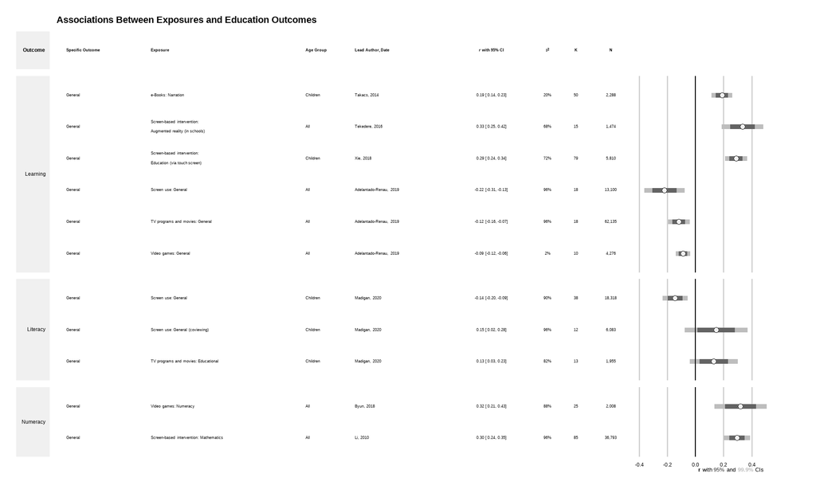

Figure 2: Education outcomes

Among the statistically credible effects, general screen use, television viewing, and video games were all negatively associated with learning. E-books that included narration, as well as touch screen education interventions, and augmented reality education interventions were positively associated with learning. General screen use was negatively associated with literacy outcomes. However, if the screen use involved co-viewing (e.g., watching with a parent), or the content of television programs was educational, the association with literacy was positive (95% CI, weak evidence). Numeracy outcomes were positively associated with screen-based mathematics interventions and video games with numeracy content.

### Health and Health-related Behaviours

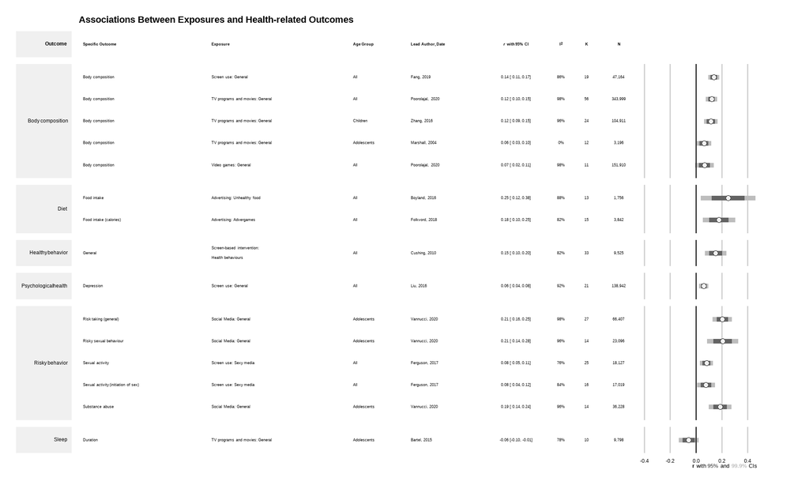

Figure 3: Health and health-related behaviour outcomes

# Discussion

The primary goal of this review was to provide a holistic perspective on the influence of screens on children’s lives across a broad domain of outcomes. We found that when meta-analyses examined general screen use, and did not specify the content, context or device, there was strong evidence showing potentially harmful associations with general learning, literacy, body composition, and depression. However, when meta-analyses included a more nuanced examination of exposures a more complex picture appeared.

Consider children watching television programs—an often cited form of screen time harm. Indeed, we find robust evidence for a small association with poorer academic performance and literacy skills [31]. However, we also found evidence that if the content of the program was education, or the child was watching the program with a parent (i.e., coviewing), this exposure was instead associated with better literacy [32]. Thus, parents play an important role in selecting content that is likely to benefit their children and, perhaps, interacting with their children in ways that may foster literacy (e.g., asking their children questions about the program). Similarly, the credible evidence we identified showed video game playing is associated with poorer body composition and learning [31,33]. When the video game was designed specifically to teach numeracy, playing these games showed learning benefits [34]. One might expect that video games designed to be physically active could confer health benefits, but none of the meta-analyses examining this hypothesis met our thresholds for statistical credibility (see Supplementary Files 4 & 5).

Social media was one type of exposure that showed consistent risks to health, with no indication of potential benefit. Social media showed strong evidence of harmful associations with risk taking in general , as well as unsafe sex and substance abuse [35]. These results align with meta-analytic evidence from adults indicates that social media use is also associated with increased risk of depression [36,37]. Recent evidence from social media companies themselves suggest there may also be negative effects of social media on the mental health of young people, especially teenage girls [38].

One category of exposure appeared to consistently confer benefits: screen-based interventions designed to promote learning or health behaviours. This finding indicates that interventions can be effectively delivered using electronic media platforms, but does not necessarily indicate that screens are more effective than other methods (e.g., face-to-face, printed material). Rather, it reinforces that the content of the screen time may be the most important aspect. Similarly, the way that a young person interacts with digital screens may also be important. We found evidence that touch screens had strong evidence for benefits on learning [30], as did augmented reality [39].

Largely owing to small number of studies or missing individual study data, there were few age-based conclusions that could be drawn from reviews which met our criteria for statistical certainty. If we expand our view to include those reviews which did meet this threshold, there remains no clear pattern. For example, advertising of unhealthy food was associated with unhealthy food choice for young children, but was not statistically significant for other age groups [40]. Conversely, TV programs and movies were more strongly associated with lower physical activity for adolescents than for younger age groups [41].

## Implications for Policy and Practice

Broadly, our findings align with the recommendations of others who suggest that current guidelines may be too simplistic, mischaracterise the strength of the evidence, or do not acknowledge the important nuances of the issue [42–44]. Instead, our findings suggest that screen use is a complex issue, with associations based not just on duration and device type, but also on the content and the environment in which the exposure occurs. Many current guidelines simplify this complex relationship as something that should be minimised in all instances. We suggest that future guidelines need to embrace the complexity of the issue, to give parents and clinicians the information to weigh the pros and cons of interactions with screens.

#### Implications for Future Research

Screen use research is big, varied, and rapidly growing. Reviews tended to be general (e.g., all screen time) and even when more targeted (e.g., social media) nuances related to specific content (e.g., Instagram vs Facebook) have not been meta-analysed or have not produced credible evidence.

Screen time research has a well-established measurement problem, which impacts the individual studies of this umbrella review. The vast majority of screen time research relies on self-reported data, which not only lacks the nuance required for understanding the effects of screen time, but may also be inaccurate. In a meta-analysis of 47 studies comparing self-reported media use with logged measures, [45] found that the measures were only moderately correlated ($r = 0.38$), with self-reported problematic usage fairing worse ($r = 0.25$). It may be that the field of screen time research cannot be sufficiently advanced until more accurate and nuanced measures are available.

#### Strengths and Limitations

Our primary goal for this umbrella review was to provide a high-level synthesis of screen time research, by examining a range of exposures and the associations with a broad scope of outcomes. Our results represent the findings from 2,171 primary studies comprised of 1,652,944 participants. To ensure findings could be compared on a common metric, we extracted and reanalysed individual study data where possible.

However, our high-level approach limits the feasibility of examining fine-grained details of the individual studies. For example, we did not examine moderators beyond age, nor did we rate the risk of bias for the individual studies. Thus, our assessment of evidence quality was restricted to statistical credibility, rather than a more complete assessment of quality (e.g., GRADE [46]). As such, we made decisions regarding the credibility of evidence, where others may have made used different thresholds or metrics. For this reason, we provide the complete results in the supplementary material, along with the dataset for others to consider alternative criteria.

# Appendix

#### Figures

- [Prisma Diagram](https://drive.google.com/file/d/1ezgeAr2WPhy6MNSESS8bhg3VMOrLAUC7/view?usp=sharing)
- [Education Outcomes](https://drive.google.com/file/d/1ODsKf3jjEGNCpUTz5tju8AHRpk_xIz-e/view?usp=sharing)
- [Health-Related Outcomes](https://drive.google.com/file/d/1wdKzliWLEFuVveAj6-MzOAsoqBhnkRJW/view?usp=sharing)

#### Tables

- [Descriptive Table](https://drive.google.com/file/d/1t5XvwY2kzsOsbZ2FxbGPsYEecZz5PgD1/view?usp=sharing)
- Supplemental tables (TBC)

#### Supplementary Files

- [Supplementary File 1: List of Reviews Without Meta-analyses](https://drive.google.com/file/d/1JhMsySEyfby5MtcUcIVpp0LjDDfTA5IH/view?usp=sharing)
- [Supplementary File 2: List of Exposures](https://drive.google.com/file/d/12rB0ihW9Hi1kxM-8AIBfjdCMO6TqP28n/view?usp=sharing)
- [Supplementary File 3: Education Outcomes Not Meeting Statistical Certainty](https://drive.google.com/file/d/1wUotZRh-jvdBJh5dkstkMtvcz7DPn-vS/view?usp=sharing)
- [Supplementary File 4: Health Outcomes Not Meeting Statistical Certainty](https://drive.google.com/file/d/1-3frrZ3woWjPqkO84Dn3_1CCaE8thIZn/view?usp=sharing)

#### Links

- [Manuscript Google Doc](https://docs.google.com/document/d/1NN4yJWQVepNjbX0mND4aidWWXcCDkg-eMepRnWdtQ9o/edit#)
- [Online Report](https://motivation-and-behaviour.github.io/screen_umbrella/)

# References

1.

Blair A. Reading Strategies for Coping With Information Overload ca.1550-1700. Journal of the History of Ideas. 2003;64(1):11–28.

2.

Bell AN. The sanitarian. Vol. 11. AN Bell; 1883.

3.

Dill KE. The Oxford handbook of media psychology. Oxford University Press; 2013.

4.

Wartella EA, Jennings N. Children and computers: New technology. Old concerns. The future of children. 2000;31–43.

5.

Rhodes A. Top ten child health problems: What the public thinks. The Royal Children’s Hospital Melbourne; 2015.

6.

The Lancet. Social media, screen time, and young people’s mental health. The Lancet. 2019;393(10172):611.

7.

Hale L, Guan S. Screen time and sleep among school-aged children and adolescents: A systematic literature review. Sleep Medicine Reviews. 2015;21:50–8.

Sweetser P, Johnson D, Ozdowska A, Wyeth P. Active versus Passive Screen Time for Young Children. Australasian Journal of Early Childhood. 2012;37(4):94–8.

9.

Li X, Atkins MS. Early childhood computer experience and cognitive and motor development. Pediatrics. 2004;113(6):1715–22.

10.

Warburton W, Highfield K. Children and technology in a smart device world. In: Children, families and communities. Oxford University Press; 2017. p. 195–221.

11.

Orben A, Przybylski AK. The association between adolescent well-being and digital technology use. Nature Human Behaviour. 2019;3(2):173–82.

12.

World Health Organization. Guidelines on physical activity, sedentary behaviour and sleep for children under 5 years of age. World Health Organization; 2019.

13.

Australian Government. Physical activity and exercise guidelines for all Australians. Department of Health; 2021.

14.

Canadian Society for Exercise Physiology. Canadian 24-Hour Movement Guidelines for Children and Youth: An Integration of Physical Activity, Sedentary Behaviour, and Sleep. Canadian Society for Exercise Physiology; 2016.

15.

Council On Communication and Media. Media Use in School-Aged Children and Adolescents. Pediatrics. 2016;138(5):e20162592.

16.

Ferguson CJ. Everything in Moderation: Moderate Use of Screens Unassociated with Child Behavior Problems. Psychiatric Quarterly. 2017;88(4):797–805.

17.

Przybylski AK, Weinstein N. A Large-Scale Test of the Goldilocks Hypothesis: Quantifying the Relations Between Digital-Screen Use and the Mental Well-Being of Adolescents. Psychological Science. 2017;28(2):204–15.

18.

Sanders T, Parker PD, del Pozo-Cruz B, Noetel M, Lonsdale C. Type of screen time moderates effects on outcomes in 4013 children: Evidence from the Longitudinal Study of Australian Children. International Journal of Behavioral Nutrition and Physical Activity. 2019;16(1):1–0.

19.

Chassiakos YLR, Radesky J, Christakis D, Moreno MA, Cross C, Council On Communication and Media. Children and Adolescents and Digital Media. Pediatrics. 2016;138(5):e20162593.

20.

National Health, Lung, and Blood Institute. Quality Assessment of Systematic Reviews and Meta-Analyses. National Health, Lung, and Blood Institute; 2014.

21.

Bonett DG. Transforming odds ratios into correlations for meta-analytic research. American Psychologist. 2007;62(3):254–5.

22.

Bowman NA. Effect Sizes and Statistical Methods for Meta-Analysis in Higher Education. Research in Higher Education. 2012;53(3):375–82.

23.

Jacobs P, Viechtbauer W. Estimation of the biserial correlation and its sampling variance for use in meta-analysis: Biserial Correlation. Research Synthesis Methods. 2017;8(2):161–80.

24.

Viechtbauer W. Metafor: Meta-analysis package for r [Internet]. 2021. Available from: https://CRAN.R-project.org/package=metafor

25.

R Core Team. R: A language and environment for statistical computing [Internet]. Vienna, Austria: R Foundation for Statistical Computing; 2021. Available from: https://www.R-project.org/

26.

Egger M, Smith GD, Schneider M, Minder C. Bias in meta-analysis detected by a simple, graphical test. BMJ. 1997;315(7109):629–34.

27.

Page MJ, Higgins JP, Sterne JA. Chapter 13: Assessing risk of bias due to missing results in a synthesis. In: Higgins JP, Thomas J, Chandler J, Cumpston M, Li T, Page MJ, et al., editors. Cochrane Handbook for Systematic Reviews of Interventions. 6.2 ed. Cochrane; 2021.

28.

Ioannidis JP, Trikalinos TA. An exploratory test for an excess of significant findings. Clinical Trials. 2007;4(3):245–53.

29.

Papadimitriou N, Markozannes G, Kanellopoulou A, Critselis E, Alhardan S, Karafousia V, et al. An umbrella review of the evidence associating diet and cancer risk at 11 anatomical sites. Nature Communications. 2021;12(1):4579.

30.

Xie H, Peng J, Qin M, Huang X, Tian F, Zhou Z. Can Touchscreen Devices be Used to Facilitate Young Children’s Learning? A Meta-Analysis of Touchscreen Learning Effect. Frontiers in Psychology. 2018;9:2580.

31.

Adelantado-Renau M, Moliner-Urdiales D, Cavero-Redondo I, Beltran-Valls MR, Martínez-Vizcaíno V, Álvarez-Bueno C. Association Between Screen Media Use and Academic Performance Among Children and Adolescents: A Systematic Review and Meta-analysis. JAMA Pediatrics. 2019;173(11):1058.

32.

Madigan S, McArthur BA, Anhorn C, Eirich R, Christakis DA. Associations Between Screen Use and Child Language Skills: A Systematic Review and Meta-analysis. JAMA Pediatrics. 2020;174(7):665.

33.

Poorolajal J, Sahraei F, Mohamdadi Y, Doosti-Irani A, Moradi L. Behavioral factors influencing childhood obesity: A systematic review and meta-analysis. Obesity Research & Clinical Practice. 2020;14(2):109–18.

34.

Byun J, Joung E. Digital game-based learning for K-12 mathematics education: A meta-analysis. School Science and Mathematics. 2018;118(3-4):113–26.

35.

Vannucci A, Simpson EG, Gagnon S, Ohannessian CM. Social media use and risky behaviors in adolescents: A meta-analysis. Journal of Adolescence. 2020;79:258–74.

36.

Yoon S, Kleinman M, Mertz J, Brannick M. Is social network site usage related to depression? A meta-analysis of Facebookdepression relations. Journal of Affective Disorders. 2019;248:65–72.

37.

Vahedi Z, Zannella L. The association between self-reported depressive symptoms and the use of social networking sites (SNS): A meta-analysis. Current Psychology. 2021;40(5):2174–89.

38.

Seetharaman GW Jeff Horwitz and Deepa. Facebook Knows Instagram Is Toxic for Teen Girls, Company Documents Show. Wall Street Journal. 2021;

39.

Tekedere H, Göke H. Examining the Effectiveness of Augmented Reality Applications in Education: A Meta-Analysis. International Journal of Environmental and Science Education. 2016;11(16):9469–81.

40.

Sadeghirad B, Duhaney T, Motaghipisheh S, Campbell NRC, Johnston BC. Influence of unhealthy food and beverage marketing on children’s dietary intake and preference: A systematic review and meta-analysis of randomized trials. Obesity Reviews. 2016;17(10):945–59.

41.

Marshall SJ, Biddle SJH, Gorely T, Cameron N, Murdey I. Relationships between media use, body fatness and physical activity in children and youth: A meta-analysis. International Journal of Obesity. 2004;28(10):1238–46.

42.

Elson M, Ferguson CJ, Gregerson M, Hogg JL, Ivory J, Klisanin D, et al. Do Policy Statements on Media Effects Faithfully Represent the Science? Advances in Methods and Practices in Psychological Science. 2019;2(1):12–25.

43.

Ashton JJ, Beattie RM. Screen time in children and adolescents: Is there evidence to guide parents and policy? The Lancet Child & Adolescent Health. 2019;3(5):292–4.

44.

Royal College of Paediatrics and Child Health. The health impacts of screen time: A guide for clinicians and parents. Royal College of Paediatrics and Child Health; 2019.

45.

Parry DA, Davidson BI, Sewall CJR, Fisher JT, Mieczkowski H, Quintana DS. A systematic review and meta-analysis of discrepancies between logged and self-reported digital media use. Nature Human Behaviour. 2021;5(11):1535–47.

46.

Guyatt G, Oxman AD, Akl EA, Kunz R, Vist G, Brozek J, et al. GRADE guidelines: 1. IntroductionGRADE evidence profiles and summary of findings tables. Journal of Clinical Epidemiology. 2011;64(4):383–94.

47.

Abrami P, Borohkovski E, Lysenko L. The effects of ABRACADABRA on reading outcomes: A meta-analysis of applied field research. Journal of Interactive Learning Research. 2015;26(4):337–67.

48.

Aghasi M, Matinfar A, Golzarand M, Salari-Moghaddam A, Ebrahimpour-Koujan S. Internet Use in Relation to Overweight and Obesity: A Systematic Review and Meta-Analysis of Cross-Sectional Studies. Advances in Nutrition. 2019;nmz073.

49.

Ameryoun A, Sanaeinasab H, Saffari M, Koenig HG. Impact of Game-Based Health Promotion Programs on Body Mass Index in Overweight/Obese Children and Adolescents: A Systematic Review and Meta-Analysis of Randomized Controlled Trials. Childhood Obesity. 2018;14(2):67–80.

50.

Anderson CA, Shibuya A, Ihori N, Swing EL, Bushman BJ, Sakamoto A, et al. Violent video game effects on aggression, empathy, and prosocial behavior in eastern and western countries: A meta-analytic review. Psychological bulletin. 2010;136(2):151.

51.

Andrade A, Correia CK, Coimbra DR. The Psychological Effects of Exergames for Children and Adolescents with Obesity: A Systematic Review and Meta-Analysis. Cyberpsychology, Behavior, and Social Networking. 2019;22(11):724–35.

52.

Aspiranti KB, Larwin KH, Schade BP. iPads/tablets and students with autism: A meta-analysis of academic effects. Assistive Technology. 2020;32(1):23–30.

53.

Barnett A, Cerin E, Baranowski T. Active video games for youth: A systematic review. Journal of Physical Activity and Health. 2011;8(5):724–37.

54.

Bartel KA, Gradisar M, Williamson P. Protective and risk factors for adolescent sleep: A meta-analytic review. Sleep medicine reviews. 2015;21:72–85.

55.

Bayraktar S. A meta-analysis of the effectiveness of computer-assisted instruction in science education. Journal of research on technology in education. 2001;34(2):173–88.

56.

Blok H, Oostdam R, Otter ME, Overmaat M. Computer-assisted instruction in support of beginning reading instruction: A review. Review of educational research. 2002;72(1):101–30.

57.

Bochner RE, Sorensen KM, Belamarich PF. The Impact of Active Video Gaming on Weight in Youth: A Meta-Analysis. Clinical Pediatrics. 2015;54(7):620–8.

58.

Bossen D, Broekema A, Visser B, Brons A, Timmerman A, van Etten-Jamaludin F, et al. Effectiveness of Serious Games to Increase Physical Activity in Children With a Chronic Disease: Systematic Review With Meta-Analysis. Journal of Medical Internet Research. 2020;22(4):e14549.

59.

Boyland EJ, Nolan S, Kelly B, Tudur-Smith C, Jones A, Halford JC, et al. Advertising as a cue to consume: A systematic review and meta-analysis of the effects of acute exposure to unhealthy food and nonalcoholic beverage advertising on intake in children and adults, 2. The American journal of clinical nutrition. 2016;103(2):519–33.

60.

Carter B, Rees P, Hale L, Bhattacharjee D, Paradkar MS. Association between portable screen-based media device access or use and sleep outcomes: A systematic review and meta-analysis. JAMA pediatrics. 2016;170(12):1202–8.

61.

Champion KE, Parmenter B, McGowan C, Spring B, Wafford QE, Gardner LA, et al. Effectiveness of school-based eHealth interventions to prevent multiple lifestyle risk behaviours among adolescents: A systematic review and meta-analysis. The Lancet Digital Health. 2019;1(5):e206–21.

62.

Chan KK, Leung SW. Dynamic geometry software improves mathematical achievement: Systematic review and meta-analysis. Journal of Educational Computing Research. 2014;51(3):311–25.

63.

Chen L, Ho SS, Lwin MO. A meta-analysis of factors predicting cyberbullying perpetration and victimization: From the social cognitive and media effects approach. New Media & Society. 2017;19(8):1194–213.

64.

Cheung AC, Slavin RE. The effectiveness of educational technology applications for enhancing mathematics achievement in K-12 classrooms: A meta-analysis. Educational research review. 2013;9:88–113.

65.

Cheung AC, Slavin RE. Effects of educational technology applications on reading outcomes for struggling readers: A best-evidence synthesis. Reading Research Quarterly. 2013;48(3):277–99.

66.

Cheung AC, Slavin RE. How features of educational technology applications affect student reading outcomes: A meta-analysis. Educational Research Review. 2012;7(3):198–215.

67.

Chodura S, Kuhn J-T, Holling H. Interventions for children with mathematical difficulties. Zeitschrift für Psychologie. 2015;

68.

Cox R, Skouteris H, Rutherford L, Fuller-Tyszkiewicz M. The Association between Television Viewing and Preschool Child Body Mass Index: A systematic review of English papers published from 1995 to 2010. Journal of Children and Media. 2012;6(2):198–220.

69.

Coyne SM, Padilla-Walker LM, Holmgren HG, Davis EJ, Collier KM, Memmott-Elison MK, et al. A meta-analysis of prosocial media on prosocial behavior, aggression, and empathic concern: A multidimensional approach. Developmental Psychology. 2018;54(2):331–47.

70.

Cushing CC, Steele RG. A Meta-Analytic Review of eHealth Interventions for Pediatric Health Promoting and Maintaining Behaviors. Journal of Pediatric Psychology. 2010;35(9):937–49.

71.

Darling KE, Sato AF. Systematic Review and Meta-Analysis Examining the Effectiveness of Mobile Health Technologies in Using Self-Monitoring for Pediatric Weight Management. Childhood Obesity. 2017;13(5):347–55.

72.

Davey S, Davey A. Assessment of smartphone addiction in Indian adolescents: A mixed method study by systematic-review and meta-analysis approach. International journal of preventive medicine. 2014;5(12):1500.

73.

de Ribera OS, Trajtenberg N, Shenderovich Y, Murray J. Correlates of youth violence in low- and middle-income countries: A meta-analysis. Aggression and Violent Behavior. 2019;49:101306.

74.

Fang K, Mu M, Liu K, He Y. Screen time and childhood overweight/obesity: A systematic review and meta-analysis. Child: Care, Health and Development. 2019;45(5):744–53.

75.

Fedele DA, Cushing CC, Fritz A, Amaro CM, Ortega A. Mobile Health Interventions for Improving Health Outcomes in Youth: A Meta-analysis. JAMA Pediatrics. 2017;171(5):461.

76.

Ferguson CJ. 13 Reasons Why Not: A Methodological and Meta-Analytic Review of Evidence Regarding Suicide Contagion by Fictional Media. Suicide and Life-Threatening Behavior. 2019;49(4):1178–86.

77.

Ferguson CJ. Do Angry Birds Make for Angry Children? A Meta-Analysis of Video Game Influences on Children’s and Adolescents’ Aggression, Mental Health, Prosocial Behavior, and Academic Performance. Perspectives on Psychological Science. 2015;10(5):646–66.

78.

Ferguson CJ, Nielsen RK, Markey PM. Does sexy media promote teen sex? A meta-analytic and methodological review. Psychiatric quarterly. 2017;88(2):349–58.

79.

Fischer P, Greitemeyer T, Kastenmüller A, Vogrincic C, Sauer A. The effects of risk-glorifying media exposure on risk-positive cognitions, emotions, and behaviors: A meta-analytic review. Psychological bulletin. 2011;137(3):367.

80.

Folkvord F, van ‘t Riet J. The persuasive effect of advergames promoting unhealthy foods among children: A meta-analysis. Appetite. 2018;129:245–51.

81.

Gao Z, Chen S, Pasco D, Pope Z. A meta-analysis of active video games on health outcomes among children and adolescents: A meta-analysis of active video games. Obesity Reviews. 2015;16(9):783–94.

82.

Gardella JH, Fisher BW, Teurbe-Tolon AR. A Systematic Review and Meta-Analysis of Cyber-Victimization and Educational Outcomes for Adolescents. Review of Educational Research. 2017;87(2):283–308.

83.

Ghobadi S, Hassanzadeh-Rostami Z, Salehi-Marzijarani M, Bellissimo N, Brett NR, Totosy de Zepetnek JO, et al. Association of eating while television viewing and overweight/obesity among children and adolescents: A systematic review and meta-analysis of observational studies: Television viewing, overweight, obesity, children. Obesity Reviews. 2018;19(3):313–20.

84.

Grabe S, Ward LM, Hyde JS. The role of the media in body image concerns among women: A meta-analysis of experimental and correlational studies. Psychological bulletin. 2008;134(3):460.

85.

Graham S, Hebert M, Harris KR. Formative assessment and writing: A meta-analysis. The Elementary School Journal. 2015;115(4):523–47.

86.

Hammersley ML, Jones RA, Okely AD. Parent-focused childhood and adolescent overweight and obesity eHealth interventions: A systematic review and meta-analysis. Journal of medical Internet research. 2016;18(7):e5893.

87.

Hernández-Jiménez C, Sarabia R, Paz-Zulueta M, Paras-Bravo P, Pellico A, Ruiz Azcona L, et al. Impact of Active Video Games on Body Mass Index in Children and Adolescents: Systematic Review and Meta-Analysis Evaluating the Quality of Primary Studies. International Journal of Environmental Research and Public Health. 2019;16(13):2424.

88.

Huang Q, Peng W, Ahn S. When media become the mirror: A meta-analysis on media and body image. Media Psychology. 2021;24(4):437–89.

89.

Hurwitz LB. Getting a Read on Ready To Learn Media: A Meta-analytic Review of Effects on Literacy. Child Development. 2019;90(5):1754–71.

90.

Janssen X, Martin A, Hughes AR, Hill CM, Kotronoulas G, Hesketh KR. Associations of screen time, sedentary time and physical activity with sleep in under 5s: A systematic review and meta-analysis. Sleep Medicine Reviews. 2020;49:101226.

91.

Kates AW, Wu H, Coryn CLS. The effects of mobile phone use on academic performance: A meta-analysis. Computers & Education. 2018;127:107–12.

92.

Kroesbergen EH, Van Luit JE. Mathematics interventions for children with special educational needs: A meta-analysis. Remedial and special education. 2003;24(2):97–114.

93.

Küçükalkan K, Beyazsaçlı M, Öz AŞ. Examination of the effects of computer-based mathematics instruction methods in children with mathematical learning difficulties: A meta-analysis. Behaviour & Information Technology. 2019;38(9):913–23.

94.

Lanca C, Saw S-M. The association between digital screen time and myopia: A systematic review. Ophthalmic and Physiological Optics. 2020;40(2):216–29.

95.

Larwin KH, Aspiranti KB. Measuring the Academic Outcomes of iPads for Students with Autism: A Meta-Analysis. Review Journal of Autism and Developmental Disorders. 2019;6(2):233–41.

96.

Lee J, Piao M, Byun A, Kim J. A systematic review and meta-analysis of intervention for pediatric obesity using mobile technology. Nursing Informatics 2016. 2016;491–4.

97.

Liao YC, Chang H, Chen Y. Effects of Computer Applications on Elementary School Students’ Achievement. Computers in the Schools. 2007;24(3):43.

98.

Liao Y-K. Effects of computer-assisted instruction on cognitive outcomes: A meta-analysis. Journal of Research on Computing in Education. 1992;24(3):367–80.

99.

Liao Y, Liao J, Durand CP, Dunton GF. Which type of sedentary behaviour intervention is more effective at reducing body mass index in children? A meta-analytic review. Obesity reviews. 2014;15(3):159–68.

100.

Li Q, Ma X. A meta-analysis of the effects of computer technology on school students’ mathematics learning. Educational Psychology Review. 2010;22(3):215–43.

101.

Liu D, Baumeister R, Yang C, Hu B. Digital Communication Media Use and Psychological Well-Being: A Meta-Analysis. Journal of Computer-Mediated Communication. 2019;24:259–73.

102.

Liu M, Wu L, Yao S. Doseresponse association of screen time-based sedentary behaviour in children and adolescents and depression: A meta-analysis of observational studies. British Journal of Sports Medicine. 2016;50(20):1252–8.

103.

Luckner H, Moss JR, Gericke CA. Effectiveness of interventions to promote healthy weight in general populations of children and adults: A meta-analysis. European Journal of Public Health. 2012;22(4):491–7.

104.

Mahdi HS, Al Khateeb AA. The effectiveness of computer-assisted pronunciation training: A meta-analysis. Review of Education. 2019;7(3):733–53.

105.

Mares M-L, Pan Z. Effects of Sesame Street: A meta-analysis of children’s learning in 15 countries. Journal of Applied Developmental Psychology. 2013;34(3):140–51.

106.

Mares M-L, Woodard E. Positive Effects of Television on Children’s Social Interactions: A Meta-Analysis. Media Psychology. 2005;7(3):301–22.

107.

Martins N, Weaver A. The role of media exposure on relational aggression: A meta-analysis. Aggression and Violent Behavior. 2019;47:90–9.

108.

McArthur G, Eve PM, Jones K, Banales E, Kohnen S, Anandakumar T, et al. Phonics training for English-speaking poor readers. Cochrane Developmental, Psychosocial and Learning Problems Group, editor. Cochrane Database of Systematic Reviews. 2012;

109.

McArthur G, Sheehan Y, Badcock NA, Francis DA, Wang H-C, Kohnen S, et al. Phonics training for English-speaking poor readers. Cochrane Developmental, Psychosocial and Learning Problems Group, editor. Cochrane Database of Systematic Reviews. 2018;2018(11).

110.

Moran J, Ferdig RE, Pearson PD, Wardrop J, Blomeyer RL. Technology and Reading Performance in the Middle-School Grades: A Meta-Analysis with Recommendations for Policy and Practice. Journal of Literacy Research. 2008;40(1):6–58.

111.

Nikkelen SWC, Valkenburg PM, Huizinga M, Bushman BJ. Media use and ADHD-related behaviors in children and adolescents: A meta-analysis. Developmental Psychology. 2014;50(9):2228–41.

112.

Oldrati V, Corti C, Poggi G, Borgatti R, Urgesi C, Bardoni A. Effectiveness of Computerized Cognitive Training Programs (CCTP) with Game-like Features in Children with or without Neuropsychological Disorders: A Meta-Analytic Investigation. Neuropsychology Review. 2020;30(1):126–41.

113.

Oliveira CB, Pinto RZ, Saraiva BTC, Tebar WR, Delfino LD, Franco MR, et al. Effects of active video games on children and adolescents: A systematic review with meta-analysis. Scandinavian Journal of Medicine & Science in Sports. 2020;30(1):4–12.

114.

Oliveira RG de, Guedes DP. Physical Activity, Sedentary Behavior, Cardiorespiratory Fitness and Metabolic Syndrome in Adolescents: Systematic Review and Meta-Analysis of Observational Evidence. Rosenfeld CS, editor. PLOS ONE. 2016;11(12):e0168503.

115.

Ozdemir M, Sahin C, Arcagok S, Demir MK. The Effect of Augmented Reality Applications in the Learning Process: A MetaAnalysis Study. Eurasian Journal of Educational Research. 2018;18:1–22.

116.

Paik H, Comstock G. The Effects of Television Violence on Antisocial Behavior: A Meta-Analysis. Communication Research. 1994;21(4):516–46.

117.

Pearce LJ, Field AP. The Impact of “Scary” TV and Film on Children’s Internalizing Emotions: A Meta-Analysis. Human Communication Research. 2016;42(1):98–121.

118.

Peng W, Lin J-H, Crouse J. Is Playing Exergames Really Exercising? A Meta-Analysis of Energy Expenditure in Active Video Games. Cyberpsychology, Behavior, and Social Networking. 2011;14(11):681–8.

119.

Prescott AT, Sargent JD, Hull JG. Metaanalysis of the relationship between violent video game play and physical aggression over time. Proceedings of the National Academy of Sciences. 2018;115(40):9882–8.

120.

Prizant-Passal S, Shechner T, Aderka IM. Social anxiety and internet use A meta-analysis: What do we know? What are we missing? Computers in Human Behavior. 2016;62:221–9.

121.

Rodriguez Rocha NP, Kim H. eHealth Interventions for Fruit and Vegetable Intake: A Meta-Analysis of Effectiveness. Health Education & Behavior. 2019;46(6):947–59.

122.

Russell SJ, Croker H, Viner RM. The effect of screen advertising on children’s dietary intake: A systematic review and meta-analysis. Obesity Reviews. 2019;20(4):554–68.

123.

Ryan AW. Meta-Analysis of Achievement Effects of Microcomputer Applications in Elementary Schools. Educational Administration Quarterly. 1991;27(2):161–84.

124.

Scherer R, Siddiq F, Sánchez Viveros B. The cognitive benefits of learning computer programming: A meta-analysis of transfer effects. Journal of Educational Psychology. 2019;111(5):764–92.

125.

Schroeder NL, Adesope OO, Gilbert RB. How Effective are Pedagogical Agents for Learning? A Meta-Analytic Review. Journal of Educational Computing Research. 2013;49(1):1–39.

126.

Scionti N, Cavallero M, Zogmaister C, Marzocchi GM. Is Cognitive Training Effective for Improving Executive Functions in Preschoolers? A Systematic Review and Meta-Analysis. Frontiers in Psychology. 2020;10:2812.

127.

Shahab L, McEwen A. Online support for smoking cessation: A systematic review of the literature. Addiction. 2009;104(11):1792–804.

128.

Shin Y, Kim SK, Lee M. Mobile phone interventions to improve adolescents’ physical health: A systematic review and meta-analysis. Public Health Nursing. 2019;36(6):787–99.

129.

Slavin RE, Lake C. Effective Programs in Elementary Mathematics: A Best-Evidence Synthesis. Review of Educational Research. 2008;78(3):427–515.

130.

Slavin RE, Lake C, Groff C. Effective Programs in Middle and High School Mathematics: A Best-Evidence Synthesis. Review of Educational Research. 2009;79(2):839–911.

131.

Slavin RE, Lake C, Hanley P, Thurston A. Experimental evaluations of elementary science programs: A best-evidence synthesis. Journal of Research in Science Teaching. 2014;51(7):870–901.

132.

Slavin RE. Reading Effects of IBM’s "Writing to Read" Program: A Review of Evaluations. Educational Evaluation and Policy Analysis. 21AD;13(1):1.

133.

Stavrinos D, Pope CN, Shen J, Schwebel DC. Distracted Walking, Bicycling, and Driving: Systematic Review and Meta-Analysis of Mobile Technology and Youth Crash Risk. Child Development. 2018;89(1):118–28.

134.

Steele JL, Bozick R, Davis LM. Education for Incarcerated Juveniles: A Meta-Analysis. Journal of Education for Students Placed at Risk (JESPAR). 2016;21(2):65–89.

135.

Strong GK, Torgerson CJ, Torgerson D, Hulme C. A systematic meta-analytic review of evidence for the effectiveness of the ‘Fast ForWord’ language intervention program. Journal of Child Psychology and Psychiatry. 2011;52(3):224–35.

136.

Takacs ZK, Swart EK, Bus AG. Benefits and Pitfalls of Multimedia and Interactive Features in Technology-Enhanced Storybooks: A Meta-Analysis. Review of Educational Research. 2015;85(4):698–739.

137.

Takacs ZK, Swart EK, Bus AG. Can the computer replace the adult for storybook reading? A meta-analysis on the effects of multimedia stories as compared to sharing print stories with an adult. Frontiers in Psychology. 2014;5.

138.

Takacs ZK, Kassai R. The efficacy of different interventions to foster children’s executive function skills: A series of meta-analyses. Psychological Bulletin. 2019;145(7):653–97.

139.

Tamim RM, Bernard RM, Borokhovski E, Abrami PC, Schmid RF. What Forty Years of Research Says About the Impact of Technology on Learning: A Second-Order Meta-Analysis and Validation Study. Review of Educational Research. 2011;81(1):4–28.

140.

Tingir S, Cavlazoglu B, Caliskan O, Koklu O, Intepe-Tingir S. Effects of mobile devices on K-12 students’ achievement: A meta-analysis: Effects of mobile devices. Journal of Computer Assisted Learning. 2017;33(4):355–69.

141.

Tremblay MS, LeBlanc AG, Kho ME, Saunders TJ, Larouche R, Colley RC, et al. Systematic review of sedentary behaviour and health indicators in school-aged children and youth. International Journal of Behavioral Nutrition and Physical Activity. 2011;8(1):98.

142.

Vahedi Z, Sibalis A, Sutherland JE. Are media literacy interventions effective at changing attitudes and intentions towards risky health behaviors in adolescents? A meta-analytic review. Journal of Adolescence. 2018;67:140–52.

143.

van Ekris E, Altenburg TM, Singh AS, Proper KI, Heymans MW, Chinapaw MJM. An evidence-update on the prospective relationship between childhood sedentary behaviour and biomedical health indicators: A systematic review and meta-analysis. Obesity Reviews. 2016;17(9):833–49.

144.

van Grieken A, Ezendam NP, Paulis WD, van der Wouden JC, Raat H. Primary prevention of overweight in children and adolescents: A meta-analysis of the effectiveness of interventions aiming to decrease sedentary behaviour. International Journal of Behavioral Nutrition and Physical Activity. 2012;9(1):1–1.

145.

van ’t Riet J, Crutzen R, Lu AS. How effective are active videogames among the young and the old? Adding meta-analyses to two recent systematic reviews. GAMES FOR HEALTH: Research, Development, and Clinical Applications. 2014;3(5):311–8.

146.

Villegas-Navas V, Montero-Simo M-J, Araque-Padilla RA. The Effects of Foods Embedded in Entertainment Media on Children’s Food Choices and Food Intake: A Systematic Review and Meta-Analyses. Nutrients. 2020;12(4):964.

147.

Wahi G, Parkin PC, Beyene J, Uleryk EM, Birken CS. Effectiveness of interventions aimed at reducing screen time in children: A systematic review and meta-analysis of randomized controlled trials. Archives of pediatrics & adolescent medicine. 2011;165(11):979–86.

148.

Weng P-L, Maeda Y, Bouck EC. Effectiveness of cognitive skills-based computer-assisted instruction for students with disabilities: A synthesis. Remedial and Special Education. 2014;35(3):167–80.

149.

Williams PA, Haertel EH, Haertel GD, Walberg HJ. The impact of leisure-time television on school learning: A research synthesis. American educational research journal. 1982;19(1):19–50.

150.

Wood W, Wong FY, Chachere JG. Effects of media violence on viewers’ aggression in unconstrained social interaction. Psychological bulletin. 1991;109(3):371.

151.

Zhang G, Wu L, Zhou L, Lu W, Mao C. Television watching and risk of childhood obesity: A meta-analysis. The European Journal of Public Health. 2016;26(1):13–8.

152.

Zhou C, Occa A, Kim S, Morgan S. A Meta-analysis of Narrative Game-based Interventions for Promoting Healthy Behaviors. Journal of Health Communication. 2020;25(1):54–65.

153.

Zucker TA, Moody AK, McKenna MC. The effects of electronic books on pre-kindergarten-to-grade 5 students’ literacy and language outcomes: A research synthesis. Journal of educational computing research. 2009;40(1):47–87.